# TidyVerse

Zachary Safir

4/10/2021

```r
library(tidyverse)
```

## Introduction

The tidyverse contains a collection of data science packages that work together in harmony to accomplish various goals. This vignette will demonstrate several ways to make full use of their combined capability.

## The Data

For this demonstration, we will use a dataset that is included with dpylr itself. It contains data on the characters from the Starwars series. Specifically, various pieces of information that describe each character.

```r
starwars
```

| name | height | mass | hair_color | skin_color | eye_color | birth_year | sex | gender | homeworld | species | films | vehicles | starships |
| --- | --- | --- | --- | --- | --- | --- | --- | --- | --- | --- | --- | --- | --- |
| Luke Skywalker | 172 | 77.0 | blond | fair | blue | 19.0 | male | masculine | Tatooine | Human |  |  |  |
| C-3PO | 167 | 75.0 | NA | gold | yellow | 112.0 | none | masculine | Tatooine | Droid |  |  |  |
| R2-D2 | 96 | 32.0 | NA | white, blue | red | 33.0 | none | masculine | Naboo | Droid |  |  |  |
| Darth Vader | 202 | 136.0 | none | white | yellow | 41.9 | male | masculine | Tatooine | Human |  |  |  |
| Leia Organa | 150 | 49.0 | brown | light | brown | 19.0 | female | feminine | Alderaan | Human |  |  |  |
| Owen Lars | 178 | 120.0 | brown, grey | light | blue | 52.0 | male | masculine | Tatooine | Human |  |  |  |
| Beru Whitesun lars | 165 | 75.0 | brown | light | blue | 47.0 | female | feminine | Tatooine | Human |  |  |  |
| R5-D4 | 97 | 32.0 | NA | white, red | red | NA | none | masculine | Tatooine | Droid |  |  |  |
| Biggs Darklighter | 183 | 84.0 | black | light | brown | 24.0 | male | masculine | Tatooine | Human |  |  |  |
| Obi-Wan Kenobi | 182 | 77.0 | auburn, white | fair | blue-gray | 57.0 | male | masculine | Stewjon | Human |  |  |  |

[output cut: 77 more lines]

Interestingly, some of the columns are full of lists. The column displayed below, shows which films a character appeared in.

```r
head(starwars$films)
```

```
## [[1]]
## [1] "The Empire Strikes Back" "Revenge of the Sith"
## [3] "Return of the Jedi"      "A New Hope"
## [5] "The Force Awakens"
##
## [[2]]
## [1] "The Empire Strikes Back" "Attack of the Clones"
## [3] "The Phantom Menace"      "Revenge of the Sith"
## [5] "Return of the Jedi"      "A New Hope"
##
## [[3]]
## [1] "The Empire Strikes Back" "Attack of the Clones"
## [3] "The Phantom Menace"      "Revenge of the Sith"
## [5] "Return of the Jedi"      "A New Hope"
## [7] "The Force Awakens"
##
## [[4]]
## [1] "The Empire Strikes Back" "Revenge of the Sith"
## [3] "Return of the Jedi"      "A New Hope"
##
## [[5]]
## [1] "The Empire Strikes Back" "Revenge of the Sith"
## [3] "Return of the Jedi"      "A New Hope"
## [5] "The Force Awakens"
##
## [[6]]
## [1] "Attack of the Clones" "Revenge of the Sith"  "A New Hope"
```

The first thing to figure out is how to pick out only characters that appear in certian films. In order to use filter from dpylr on a list, we need to use a purr function with it. As filter is expecting a logical value, we need to return something logical. Using map_lgl, we can accomplish this.

```r
starwars %>%
filter(map_lgl(films,~ "Attack of the Clones" %in% .))
```

| name | height | mass | hair_color | skin_color | eye_color | birth_year | sex | gender | homeworld | species | films | vehicles | starships |
| --- | --- | --- | --- | --- | --- | --- | --- | --- | --- | --- | --- | --- | --- |
| C-3PO | 167 | 75.0 | NA | gold | yellow | 112.0 | none | masculine | Tatooine | Droid |  |  |  |
| R2-D2 | 96 | 32.0 | NA | white, blue | red | 33.0 | none | masculine | Naboo | Droid |  |  |  |
| Owen Lars | 178 | 120.0 | brown, grey | light | blue | 52.0 | male | masculine | Tatooine | Human |  |  |  |
| Beru Whitesun lars | 165 | 75.0 | brown | light | blue | 47.0 | female | feminine | Tatooine | Human |  |  |  |
| Obi-Wan Kenobi | 182 | 77.0 | auburn, white | fair | blue-gray | 57.0 | male | masculine | Stewjon | Human |  |  |  |
| Anakin Skywalker | 188 | 84.0 | blond | fair | blue | 41.9 | male | masculine | Tatooine | Human |  |  |  |
| Yoda | 66 | 17.0 | white | green | brown | 896.0 | male | masculine | NA | Yoda's species |  |  |  |
| Palpatine | 170 | 75.0 | grey | pale | yellow | 82.0 | male | masculine | Naboo | Human |  |  |  |
| Boba Fett | 183 | 78.2 | black | fair | brown | 31.5 | male | masculine | Kamino | Human |  |  |  |
| Nute Gunray | 191 | 90.0 | none | mottled green | red | NA | male | masculine | Cato Neimoidia | Neimodian |  |  |  |

[output cut: 30 more lines]

In order to use filter on multiple values, we need to use the base R function “all”.

```r
starwars %>%
filter(map_lgl(films,~ all( c("Attack of the Clones","A New Hope") %in% .)))
```

| name | height | mass | hair_color | skin_color | eye_color | birth_year | sex | gender | homeworld | species | films | vehicles | starships |
| --- | --- | --- | --- | --- | --- | --- | --- | --- | --- | --- | --- | --- | --- |
| C-3PO | 167 | 75 | NA | gold | yellow | 112 | none | masculine | Tatooine | Droid |  |  |  |
| R2-D2 | 96 | 32 | NA | white, blue | red | 33 | none | masculine | Naboo | Droid |  |  |  |
| Owen Lars | 178 | 120 | brown, grey | light | blue | 52 | male | masculine | Tatooine | Human |  |  |  |
| Beru Whitesun lars | 165 | 75 | brown | light | blue | 47 | female | feminine | Tatooine | Human |  |  |  |
| Obi-Wan Kenobi | 182 | 77 | auburn, white | fair | blue-gray | 57 | male | masculine | Stewjon | Human |  |  |  |

We can also use tidyr in order to flatten our lists full of data out. The resulting dataframe of this action is shown below.

```r
starwars %>%
  select(name,films) %>%
  unnest(films)
```

| name | films |
| --- | --- |
| Luke Skywalker | The Empire Strikes Back |
| Luke Skywalker | Revenge of the Sith |
| Luke Skywalker | Return of the Jedi |
| Luke Skywalker | A New Hope |
| Luke Skywalker | The Force Awakens |
| C-3PO | The Empire Strikes Back |
| C-3PO | Attack of the Clones |
| C-3PO | The Phantom Menace |
| C-3PO | Revenge of the Sith |
| C-3PO | Return of the Jedi |

[output cut: 163 more lines]

With our data in a normal format, we can use the dpylr count function to discover which film is most common.

```r
starwars %>%
  unnest(films) %>%
  count(films) %>%
  arrange(n)
```

| films | n |
| --- | --- |
| The Force Awakens | 11 |
| The Empire Strikes Back | 16 |
| A New Hope | 18 |
| Return of the Jedi | 20 |
| Revenge of the Sith | 34 |
| The Phantom Menace | 34 |
| Attack of the Clones | 40 |

Another interesting function comes from forcats. In the previous example, we had a small number of a categories. However, quite often we will have a handful of common categories, and a whole bunch of other smaller groups. In such a case, we can use the forcats fct_lump to grab the most common categories, and lump the least most into a Other category.

```r
starwars %>%
  filter(!is.na(homeworld)) %>%
  mutate(homeworld = fct_lump(homeworld, n = 3)) %>%
  count(homeworld) %>%
  arrange(n)
```

| homeworld | n |
| --- | --- |
| Alderaan | 3 |
| Coruscant | 3 |
| Kamino | 3 |
| Tatooine | 10 |
| Naboo | 11 |
| Other | 47 |

Finally, we will demonstrate the fct_infreq function. In the first plot shown below, by default the plot is not ordered in any kind of way. However, by using fct_infreq in the second plot, we are able to reorder the values by their frequency in the data.

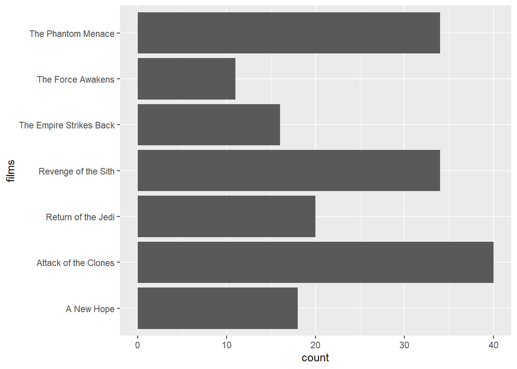

```r
starwars %>%
  unnest(films) %>%
  ggplot(aes(films)) +
    geom_bar() +
    coord_flip()
```

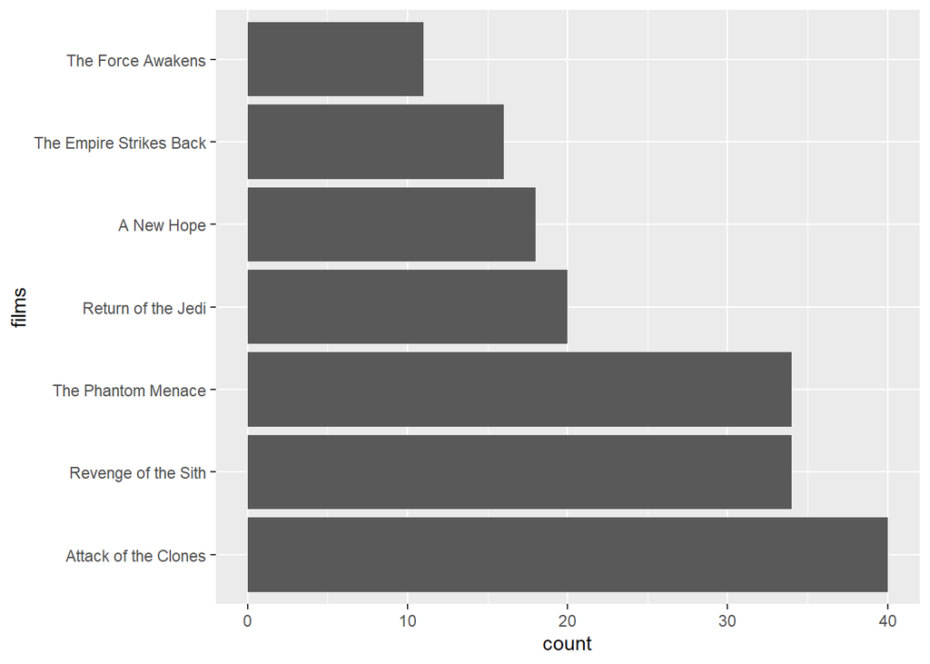

```r
starwars %>%
  unnest(films) %>%
  mutate(films = fct_infreq(films)) %>%
  ggplot(aes(films)) +
    geom_bar() +
    coord_flip()
```